# MATH5741M: Statistical Theory and Methods

Benjamin Thorpe

2021-10-20

Benjamin Thorpe (b.thorpe@leeds.ac.uk)  
Wednesday October 20, 2021

# 4 Estimation

## 4.1 Method of moments

We have seen six different probability distributions so far. Although these distributions seemed like sensible models for our random variables, there is a major obstacle: **in practice, we don’t actually know the true values of their parameters**.

For example, we proposed a model for the random variable “years between first and last kill” based on an exponential distribution. But we were unable to calculate any probabilities without assuming a value for the parameter. We ideally need a way to sensibly **estimate** the parameter from a sample of observations from our distribution.

We have seen some examples of estimation already. For example, we modelled number of convictions as a Poisson random variable, $X \sim \text{Po}(\lambda)$, and estimated $\lambda$ using the sample mean of $\overline{x} = 239/100$. This was based on the interpretation of $\lambda$ as a rate, convictions per killer, and the fact that our sample had $100$ killers with a total of $239$ convictions. Given that $239/100$ is the sample mean, this estimate seems even more sensible now that we know $\lambda = {\mathsf E}(X)$ is the population mean for a Poisson distribution.

Taking this idea further, for an exponentially distributed variable $X \sim \text{Exp}(\lambda)$ we know that the population mean is ${\mathsf E}(X) = 1/\lambda$. So, if we observe a sample $\{x_{1}, \ldots, x_{n}\}$ from this distribution, then we might assume that the sample mean is a good estimate of the population mean:
$$\frac{1}{\lambda} \approx \overline{x}$$
and then solve for $\lambda$ to get an estimate $\lambda \approx {1}/{\overline{x}}$.

In summary, if there is **one** unknown parameter then we might write the distribution’s mean in terms of that parameter (see the table at the end of the previous chapter), set this equal to the sample mean, and then solve this **one** equation to obtain an estimate for the parameter in terms of the sample mean. This method of estimation is the **method of moments (MOM)**.

The method of moments is often easy to implement and seems like a natural choice. We happily applied it without much thought in previous sections. However, we didn’t choose this method based on any meaningful criterion, other than the fact that it seemed obvious. We should really choose some criterion by which we might determine the “best” estimator for a given parameter. For example, we can try to choose the estimator that maximises the likelihood of the observed data.

## 4.2 Maximum likelihood

**Example 4.1 (globular clusters)** A globular cluster is a dense collection of stars that orbits the core of a galaxy. Understanding the properties of globular clusters is important for understanding galaxy evolution.[^1] Let $X$ denote the random variable “number of globular clusters”, which varies from galaxy to galaxy.

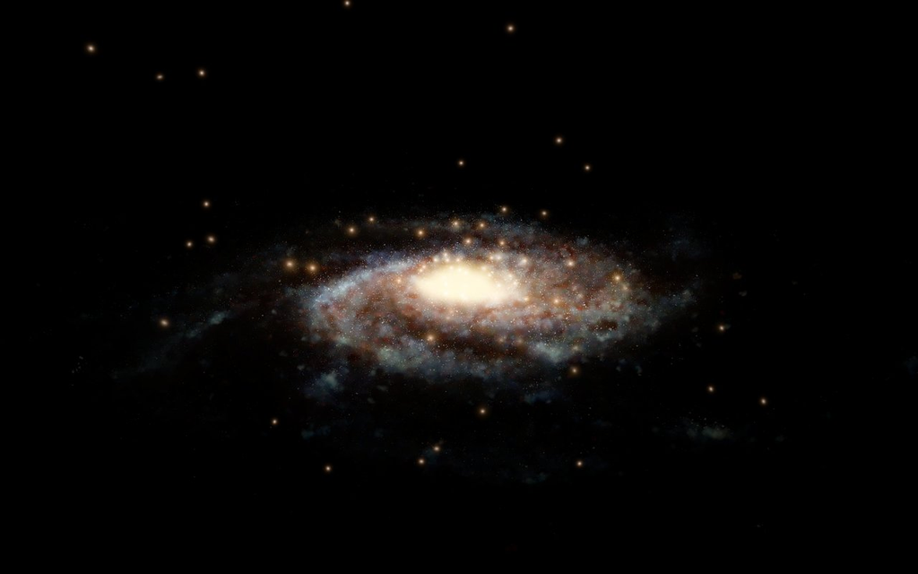

Figure 4.1: An artist’s impression of the Milky Way. Globular clusters are shown surrounding the galaxy. Credit: ESA/Hubble, NASA, L Calcada, M Kormesser. https://www.spacetelescope.org/news/heic1905/

Suppose that we take a random sample of $n = 3$ galaxies and observe[^2]
$$\{x_{1}, x_{2}, x_{3}\} = \{10, 50, 90\}.$$

We propose a Poisson model $X \sim \text{Po}(\lambda)$. But how can we estimate $\lambda$ from our data? We should consider the relationship between our observed sample and $\lambda$. We know that
$${\mathsf P}(X = x) = f(x) = \frac{\lambda^{x}e^{-\lambda}}{x!}\;.$$
Since our sample is from the distribution of $X$, we have $X_{i} \sim \text{Po}(\lambda)$ for $i = 1,2,3$. Therefore
$${\mathsf P}(X_{1} = 10) = f(10),$$
$${\mathsf P}(X_{2} = 50) = f(50),$$
$${\mathsf P}(X_{3} = 90) = f(90).$$
The overall probability of our observed sample,
$${\mathsf P}(\{X_{1} = 10\} \cap \{X_{2} = 50\} \cap \{X_{3} = 90\}),$$
can then (by independence) be written as a product
$$\begin{eqnarray*}
{\mathsf P}(X_{1} = 10){\mathsf P}(X_{2} = 50){\mathsf P}(X_{3} = 90) & = & f(10)f(50)f(90)\\
& = & \frac{\lambda^{10}e^{-\lambda}}{10!} \frac{\lambda^{50}e^{-\lambda}}{50!} \frac{\lambda^{90}e^{-\lambda}}{90!}\\
& = & \frac{\lambda^{150}e^{-3\lambda}}{10! 50! 90!}\\
& = & L(\lambda),
\end{eqnarray*}$$
which is a function of $\lambda$. We call this the **likelihood** of the sample.

Now we ask the obvious question: **for which value of the parameter $\lambda$ would the observed data be most likely to occur?** There are infinitely many **possible** values of $\lambda$, but we want to find one for which $L(\lambda)$ is maximised. This is illustrated in Figure 4.2.

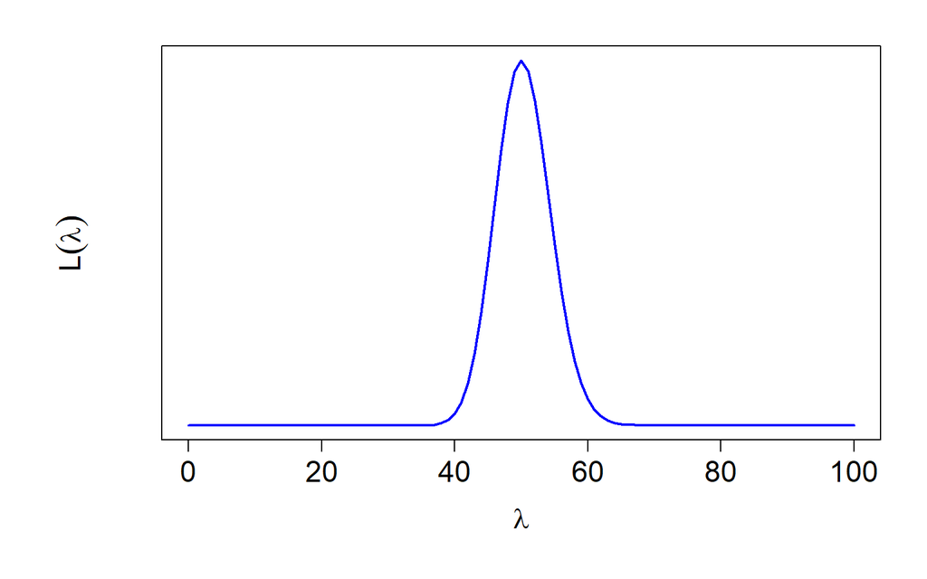

Figure 4.2: A plot of the likelihood function for our observed sample. The curve has a very clear peak somewhere between $40$ and $60$ clusters per galaxy. We need to find the value of $\lambda$ for which this peak is achieved.

So we find a candidate for this maximiser by differentiating $L(\lambda)$ and solving
$$\begin{eqnarray*}
0 & = & \frac{d}{d\lambda}L(\lambda)\\
& = & \frac{150\lambda^{150 - 1}e^{-3\lambda} - 3\lambda^{150}e^{-3\lambda}}{10!50!90!} \\
& = & \frac{\left(150 - 3\lambda\right)\lambda^{149}e^{-3\lambda}}{10!50!90!}
\end{eqnarray*}$$
which is equivalent to $150 = 3\lambda$ or $\lambda = 0$. Then, since we know $\lambda > 0$ for a Poisson distribution, we get
$$\lambda = \frac{150}{3} = 50.$$
We can check if this maximises $L(\lambda)$ by differentiating again and checking the sign of
$$\frac{d^2 L}{d\lambda^2} = \frac{- 3\lambda^{149}e^{-3\lambda} + 149\left(150 - 3\lambda\right)\lambda^{148}e^{-3\lambda} - 3\left(150 - 3\lambda\right)\lambda^{149}e^{-3\lambda}}{10!50!90!}$$
when $\lambda = 50$. Clearly
$$\frac{d^2 L}{d\lambda^2}(50) = \frac{- 3\times 50^{149}e^{-3\times 50} + 0 + 0}{10!50!90!} <0$$
and therefore $L(\lambda)$ has a maximum point at $\lambda = 50$. In conclusion, our estimate for $\lambda$ is
$$\widehat{\lambda} = \frac{150}{3} = 50.$$
This is the parameter for which the observed sample is most likely to have occurred. In other words, a rate of $50$ clusters per galaxy is more likely to produce the sample $\{10, 50, 90\}$ than any other possible rate. Therefore this value of $\lambda$ might be considered the best explanation of our observed data.

**Definition 4.1** Let $X$ be a random variable whose mass/density function, $f(x)$, depends on an unknown parameter $\theta$. Suppose that we take an IID random sample of size $n$ from this distribution. The **likelihood** of observing $\{x_1, \ldots, x_n\}$ is
$$L(\theta) = f(x_{1})f(x_{2})\ldots f(x_{n})$$
and is treated as a function of $\theta$ (not as a function of the data $x_{1},\ldots, x_{n}$). A **maximum likelihood estimate (MLE)** of $\theta$ is a value which maximises $L(\theta)$.

Our definition can be easily generalised to include distributions that depend on multiple unknown parameters or samples that are not independent.

The likelihood is a product, so it can be difficult to differentiate and to maximise. It is often much easier (but equivalent) to maximise its logarithm.

**Definition 4.2** If $L(\theta)$ is a likelihood then the **log likelihood** is $\ell(\theta) = \log L(\theta).$

Here, $\log$ denotes the natural logarithm (sometimes denoted $\ln$ in books and other courses). Since $\log$ is an increasing function, any $\theta$ that maximises $\ell$ will also maximise $L$.

**Example 4.2 (globular clusters, continued)** Our estimate was based on a single sample, $\{x_{1}, x_{2}, x_{3}\} = \{10, 50, 90\}$. But somebody else might observe a very different sample, and thus a different estimate for $\lambda$. So we now consider a general sample
$$x_{1}, \ldots, x_{n}.$$
Can we write down a general formula for the maximum likelihood estimate?

$$\begin{eqnarray*}
L(\lambda) & = & f(x_{1})f(x_{2})\ldots f(x_{n})\\
& = & \frac{\lambda^{x_1}e^{-\lambda}}{x_1!} \frac{\lambda^{x_2}e^{-\lambda}}{x_2!} \cdots \frac{\lambda^{x_n}e^{-\lambda}}{x_n!}\\
& = & \frac{1}{x_1!x_2!\cdots x_n!}\lambda^{\sum_{i=1}^{n}x_i} e^{-n\lambda}.
\end{eqnarray*}$$
and therefore the log likelihood is
$$\begin{eqnarray*}
\ell(\lambda) & = & \log L(\lambda)\\
& =& \log \frac{1}{x_1!x_2!\cdots x_n!} + \log \lambda^{\sum_{i=1}^{n}x_i} +\log e^{-n\lambda}\\
& = & -\log\left(x_1!x_2!\cdots x_n!\right) + \left(\sum_{i=1}^{n}x_i\right)\log\lambda - n\lambda
\end{eqnarray*}$$
Differentiating this, we get
$$\frac{d \ell}{d \lambda}(\lambda) = 0 + \frac{1}{\lambda}\sum_{i=1}^{n}x_{i} - n.$$
Solving $\frac{d \ell}{d \lambda}(\lambda) = 0$ for $\lambda$ gives us
$$\lambda = \frac{\sum_{i=1}^{n}x_i}{n} = \overline{x},$$
so a candidate for our estimate is $\widehat{\lambda} = \overline{x}$. We check if this gives a maximum:
$${\frac{d^2 \ell}{d \lambda^2}(\lambda) = \frac{-1}{\lambda^2}\sum_{i=1}^{n}x_{i}}$$
which, when evaluated at $\widehat{\lambda}$, gives
$$\begin{eqnarray*}
\frac{d^2 \ell}{d \lambda^2}(\widehat{\lambda}) = \frac{-1}{\widehat{\lambda}^2}\sum_{i=1}^{n}x_{i}
= \frac{-1}{{\overline{x}}^2}\underbrace{\sum_{i=1}^{n}x_{i}}_{n\overline{x}}
= -\frac{n}{\overline{x}}
\end{eqnarray*}$$
But a Poisson random variable only takes non-negative values, so each $x_{i} \geq 0$ and therefore $\overline{x}\geq 0$. So if $\overline{x} > 0$ then we have ${\frac{d^2 \ell}{d \lambda^2}(\widehat{\lambda}) < 0}$ and therefore our MLE is
$$\widehat{\lambda} = \overline{x}.$$
If $\overline{x} = 0$ then the entire sample must consist of $n$ zeros (i.e. a sample of galaxies where none have globular clusters), so $\ell(\lambda) = -n\lambda$ which does not have a maximum, since $\lambda > 0$, hence there is no MLE in this specific case.

## 4.3 General concepts

In our globular clusters example, other researchers might observe different galaxies and thus obtain a different estimates. Suppose that four researchers take random samples of galaxies and observe
$$\begin{eqnarray*}
\{4670, 320, 3000\} &\quad \Rightarrow \quad & \widehat{\lambda}=2663,\\
\{196, 1242, 300\} &\quad \Rightarrow \quad & \widehat{\lambda}=579,\\
\{160, 376, 120\} &\quad \Rightarrow \quad & \widehat{\lambda}=219,\\
\{550, 160, 1100\} &\quad \Rightarrow \quad & \widehat{\lambda}=603.\\
\end{eqnarray*}$$
Of course, these four different samples give us four different MLEs. We can think of $\widehat{\lambda}$ as a function that maps each realised sample to a possible value of $\lambda$:
$$\widehat{\lambda} = \widehat{\lambda}(x_{1}, \ldots, x_{n}) = \overline{x} = \frac{\sum_{i=1}^{n}x_{i}}{n}.$$

But each $x_{i}$ is a realisation of a random variable $X_{i}$. So we could also think of $\widehat{\lambda}$ as a random quantity by writing:
$$\widehat{\lambda} = \widehat{\lambda}(X_{1}, \ldots, X_{n}) = \overline{X} = \frac{\sum_{i=1}^{n}X_{i}}{n},$$
which is a statistic that varies randomly from sample to sample. This leads us to the following general definition.

**Definition 4.3** Consider a random sample $X_{1}, \ldots, X_{n}$ from a distribution that depends on a parameter $\theta$. Consider any function
$$x_{1}, \ldots, x_{n} \;\; \mapsto \;\; \widehat{\theta}(x_{1}, \ldots, x_{n})$$
that will map any realisation of our random sample to a possible parameter value. For a given realisation, the number
$$\widehat{\theta}(x_{1}, \ldots, x_{n})$$
is an **estimate** of $\theta$. The random quantity
$$\widehat{\theta}(X_{1}, \ldots, X_{n}),$$
is an **estimator** of $\theta$. Its distribution is called its **sampling distribution**.

The important part of this definition is that an estima**te** $\widehat{\theta}(x_{1}, \ldots, x_{n})$ is a fixed number (not random). An estimate is a realisation of the estima**tor** $\widehat{\theta}(X_{1}, \ldots, X_{n})$, which we think of as random. To keep our notation simple, we usually denote both the estimate and estimator by just $\widehat{\theta}$, but the meaning should always be clear from the context.

This might all seem unnecessarily abstract, but it is actually a very useful idea. By understanding that our estimate is itself just an observation from some probability distribution, we can use this distribution to understand how accurately it estimates $\theta$.

This definition is also very general. The estimator is not necessarily an MLE or MOM estimator. We can come up with many different estimators for a parameter. How can we decide which to use? We should compare features of their sampling distributions (e.g. expectations and variances) to decide which of them estimates the parameter more accurately.

**Example 4.3 (globular clusters, continued)** Thinking of the estimator $\widehat{\lambda} = \overline{X}$ as a random variable with a sampling distribution, what is the expectation of $\widehat{\lambda}$ across all possible samples of size $n$? We know that expectation is linear and that the expectation of a sum is the sum of the expectations, and therefore
$$\begin{eqnarray*}
{\mathsf E}(\widehat{\lambda}) & = & {\mathsf E}\left(\frac{\sum_{i=1}^{n}X_{i}}{n}\right) \\
& = & \frac{1}{n}{\mathsf E}\left(\sum_{i=1}^{n}X_{i}\right)
= \frac{1}{n}\sum_{i=1}^{n}{\mathsf E}(X_{i}).
\end{eqnarray*}$$
We also assume that each variable in our sample comes from a Poisson distribution, $X_{i} \sim \text{Po}(\lambda)$. Therefore we know, as seen in the table at the end of Chapter 3, ${\mathsf E}(X_{i}) = \lambda$, which implies
$$\begin{eqnarray*}
{\mathsf E}(\widehat{\lambda}) & = & \frac{1}{n}\sum_{i=1}^{n}{\mathsf E}(X_{i})\\
& = & \frac{1}{n}\sum_{i=1}^{n}\lambda
= \frac{1}{n} n\lambda
= \lambda.
\end{eqnarray*}$$
So the expected value of the estimator $\widehat{\lambda}$ (i.e. the average of $\widehat{\lambda}$ across all possible samples) is equal to the true value of $\lambda$. In other words, our estimator will be correct “on average”. We say $\widehat{\lambda}$ is unbiased.

**Definition 4.4** Let $\widehat{\theta}$ be an estimator for $\theta$. The **bias** of $\widehat{\theta}$ is
$$\text{bias}(\widehat{\theta})= {\mathsf E}(\widehat{\theta})-\theta.$$
$\widehat{\theta}$ is **unbiased** for $\theta$ if $\text{bias}(\widehat{\theta}) \equiv 0,$ which is equivalent to ${\mathsf E}(\widehat{\theta})= \theta$ for all possible $\theta$.

$\text{bias}(\widehat{\theta})$ often depends on the unknown parameter $\theta$, rather than being some known number. It is important to remember that $\widehat{\theta}$ is only unbiased if ${\mathsf E}(\widehat{\theta})=\theta$ for **all possible values of** $\theta$. It is not enough to just find some specific value of $\theta$ for which this holds.

Bias is an undesirable (but often unavoidable) property. We prefer an estimate that is either unbiased or has a bias as small as possible. For example, in Figure 4.3, we have three hypothetical estimators for the same parameter. It appears that Estimator 1 is distributed symmetrically about the true value of the parameter and might therefore be unbiased.

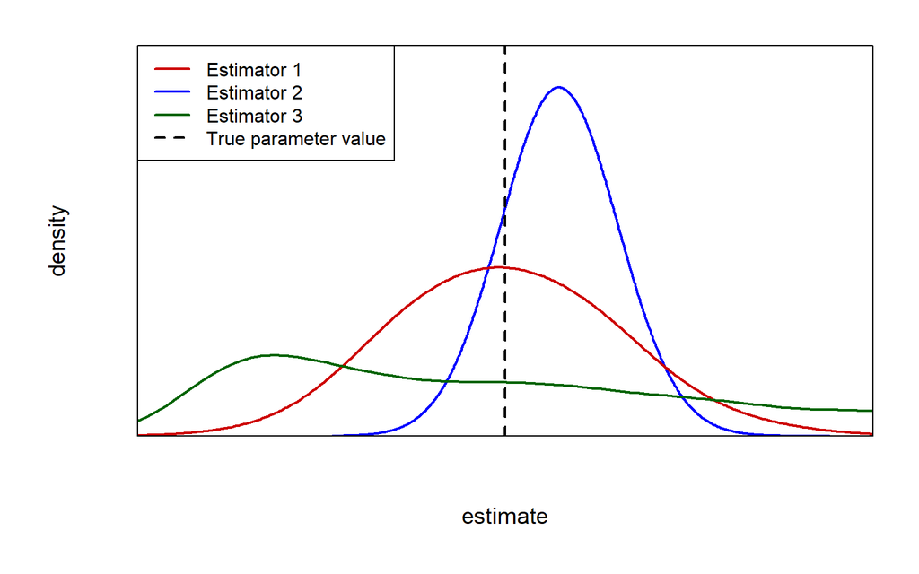

Figure 4.3: Density functions of the sampling distributions of three estimators. It is important to note that these curves represent the distributions of the estimators, not the distribution from which samples are taken (which is assumed to be the same for all three estimators).

The other two estimators appears to be biased, such that Estimator 2 will tend to overestimate the parameter (positive bias) and Estimator 3 will tend to underestimate it (negative bias). Estimator 3 appears to be a particularly poor estimator because it also has a very large variance and is therefore likely to produce estimates quite far from the parameter.

However, despite being biased, Estimator 2 has the distribution most concentrated near the true value of the parameter. It might therefore be very likely to produce estimates that are close to the truth. This might be enough to make it preferable to the unbiased Estimator 1, whose distribution has quite a large spread.

It’s unclear which estimator is best. We must weigh the disadvantages of having a systematic bias against the advantages of having a concentrated distribution. The following definition gives us a tool that we can use to compare estimators while taking into account both of these properties.

**Definition 4.5** Let $\widehat{\theta}$ be an estimator of $\theta$. The **mean squared error (MSE)** of $\widehat{\theta}$ is
$$\text{MSE} (\widehat{\theta}) = {\mathsf E}\big[ \; (\widehat{\theta} - \theta)^2 \; \big].$$

This definition clearly shows why the MSE is of interest: it measures the variability of the estimator about the true value of the parameter. The smaller the MSE of an estimator, the closer the estimates we get from it will tend to be to the true (unknown) value of the parameter. We can use this as a criterion for choosing between estimators.

However, based on this definition alone, it can be difficult to determine whether an estimator has a small MSE or not. Alternatively, we can express the MSE in terms of the bias and the variance of the estimator, as shown in the following theorem. This is the expression that we usually work with in practice.

**Theorem 4.1** Let $\widehat{\theta}$ be an estimator of $\theta$, then
$$\text{MSE} (\widehat{\theta}) = \text{var}(\widehat{\theta}) + \text{bias}(\widehat{\theta})^2.$$

*Proof.* Using the linearity properties of expectation, we can write the right hand side as
$$\begin{eqnarray*}
\text{MSE} (\widehat{\theta}) & = & {\mathsf E}\left(\widehat{\theta}^2 - 2\widehat{\theta}\theta +\theta^2 \right)\\
& = & {\mathsf E}( \widehat{\theta}^2) - 2{\mathsf E}(\widehat{\theta})\theta +\theta^2. \\
%& = & \EE( \widehat{\theta}^2) \underbrace{- [\EE(\widehat{\theta})^2]+ [\EE(\widehat{\theta})^2]}_{=0} - 2\EE(\widehat{\theta})\theta+\theta^2 \\
%& =& \text{var}(\widehat{\theta}) + (\EE(\widehat{\theta})-\theta)^2\\
%& =& \text{var}(\widehat{\theta}) + \text{bias}(\widehat{\theta})^2
\end{eqnarray*}$$

The left hand side is
$$\begin{eqnarray*}
\text{var}(\widehat{\theta}) + \text{bias}(\widehat{\theta})^2 & = & \left[{\mathsf E}( \widehat{\theta}^2) - {\mathsf E}(\widehat{\theta})^2\right] + \left[{\mathsf E}(\widehat{\theta})-\theta\right]^2\\
& = & {\mathsf E}( \widehat{\theta}^2) - 2{\mathsf E}(\widehat{\theta})\theta +\theta^2.
\end{eqnarray*}$$
Therefore
$$\text{MSE} (\widehat{\theta}) = \text{var}(\widehat{\theta}) + \text{bias}(\widehat{\theta})^2.\qquad\qquad\large\square$$

Looking again at Figure 4.3, it is fairly clear that Estimator 3 should have the highest MSE, since it is biased with a large variance. Estimator 2 is biased with a small variance, while Estimator 1 appears to be unbiased but has a high variance. It’s not clear which of the two has a smaller MSE. We would need to calculate both MSEs for a more meaningful comparison.

**Example 4.4 (globular clusters, continued)** Thinking of $\widehat{\lambda} = \overline{x}$ as a random variable again, we already know that $\text{bias}(\widehat{\lambda})$ is $0$. So we just need the variance of $\widehat{\lambda}$.
$$\begin{eqnarray*}
\text{var}(\widehat{\lambda}) = \text{var}\left(\frac{1}{n}\sum_{i=1}^{n}X_{i}\right) = \frac{1}{n^2}\text{var}\left(\sum_{i=1}^{n}X_{i}\right)
\end{eqnarray*}$$
by the scaling properties of variance. Now we recall that the variance of a sum of independent random variables is the sum of their individual variances,
$$\begin{eqnarray*}
\text{var}(\widehat{\lambda})
%& = & \frac{1}{n^2}\text{var}\left(X_{1} + X_{2} + X_{3} + \ldots + X_{n}\right)\\
%& = & \frac{1}{n^2}\Big[\;\text{var}\left(X_{1}\right) + \text{var}\left(X_{2} + X_{3} + \ldots + X_{n}\right)\;\Big]\\
%& = & \frac{1}{n^2}\Big[\;\text{var}\left(X_{1}\right) + \text{var}\left(X_{2}\right) + \text{var}\left(X_{3} + \ldots + X_{n}\right)\;\Big]\\
%& \vdots & \\
%& = & \frac{1}{n^2}\Big[\;\text{var}\left(X_{1}\right) + \text{var}\left(X_{2}\right) + \text{var}\left(X_{3}\right) + \ldots + \text{var}\left(X_{n}\right)\;\Big]\\
& = & \frac{1}{n^2}\sum_{i=1}^{n}\text{var}(X_{i}).
\end{eqnarray*}$$
But we also know the $X_{i}\sim \text{Po}(\lambda)$, and therefore $\text{var}(X_{i}) = \lambda$, as seen in the table at the end of the previous chapter. We get
$$\begin{eqnarray*}
\text{var}(\widehat{\lambda}) & = & \frac{1}{n^2}\sum_{i=1}^{n}\lambda = \frac{1}{n^2}n \lambda = \frac{\lambda}{n}.
\end{eqnarray*}$$
Therefore, the MSE of our estimate is ${\lambda}/{n} + 0^2 = {\lambda}/{n}$. This is good because it means that we can make the MSE as small as we like just by taking the sample size to be large enough.

[^1]: de Souza et al. “The overlooked potential of generalized linear models in astronomy III - Bayesian negative binomial regression and globular cluster populations”, Monthly Notices of the Royal Astronomical Society, Volume 453, Issue 2, 21 October 2015.
[^2]: This sample comes from a real data set: https://www.physics.mcmaster.ca/~harris/GCS_table.txt. For further details, see Harris et al. “A catalog of globular cluster systems: what determines the size of a galaxy’s globular cluster population?”, Astrophysical Journal, Volume 772, Number 2, July 2013. A larger sample of observations is available in `galaxies.Rdata` on Minerva.